# Tugas Pertemuan 6

# LIBRARY

```r
library(readxl)
library(ggplot2)
library(tsibble)
library(tseries)
library(MASS)
library(forecast)
library(TSA)
library(TTR)
library(aTSA)
library(graphics)
```

# INPUT DATA KUALITAS UDARA

## Input Dataset

```r
dt<-read_excel("D:\\KULIAH\\Semester 5\\DATA SEMESTER 5\\Air Quality Index.xlsx", sheet="Anggota_1")
dt
```

```
## # A tibble: 156 × 2
##        t `PM2.5(ug/m3)`
##    <dbl>          <dbl>
##  1     1           69.3
##  2     2           56.4
##  3     3           40.1
##  4     4           49.7
##  5     5           49.3
##  6     6           59.8
##  7     7           71.7
##  8     8           61.3
##  9     9           52.6
## 10    10           51.6
## # ℹ 146 more rows
```

## Bagi Menjadi Data Train & Test

```r
dt.test <- dt[126:156,]
dt.train <- dt[1:125,]
dt.test
```

```
## # A tibble: 31 × 2
##        t `PM2.5(ug/m3)`
##    <dbl>          <dbl>
##  1   126           76.8
##  2   127           94.1
##  3   128           92.6
##  4   129          106.
##  5   130          104.
##  6   131           75.1
##  7   132           69
##  8   133           66.9
##  9   134           68.4
## 10   135           80.2
## # ℹ 21 more rows
```

```r
str(dt.train)
```

```
## tibble [125 × 2] (S3: tbl_df/tbl/data.frame)
##  $ t           : num [1:125] 1 2 3 4 5 6 7 8 9 10 ...
##  $ PM2.5(ug/m3): num [1:125] 69.3 56.4 40.1 49.7 49.3 ...
```

# EKSPLORASI

## Plot Time-Series

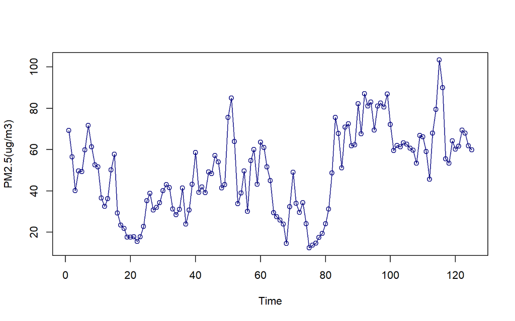

```r
plot(dt.train,
     col = "navyblue",
     lwd = 1,
     type = "o",
     xlab = "Time",
)
```

# CEK KESTASIONERAN

## Plot ACF

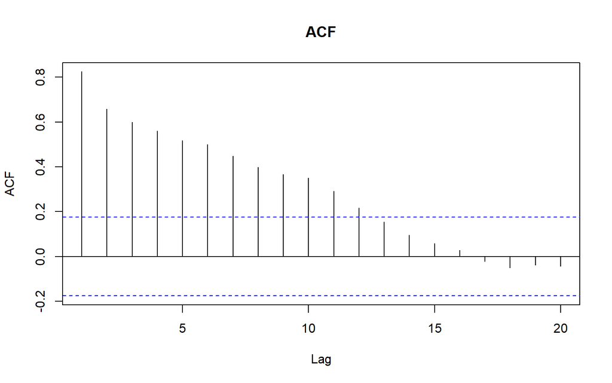

```r
acf(dt.train$`PM2.5(ug/m3)`, main ="ACF",lag.max=20)
```

## Uji Formal ADF

```r
tseries::adf.test(dt.train$`PM2.5(ug/m3)`)
```

```
##
##  Augmented Dickey-Fuller Test
##
## data:  dt.train$`PM2.5(ug/m3)`
## Dickey-Fuller = -2.8075, Lag order = 4, p-value = 0.241
## alternative hypothesis: stationary
```

$H_0$ : Data tidak stasioner dalam rataan

$H_1$ : Data stasioner dalam rataan

Berdasarkan uji ADF tersebut, didapat *p-value* sebesar 0.241 yang lebih besar dari taraf nyata 5% sehingga gagal tolak $H_0$ dan menandakan bahwa data tidak stasioner dalam rataan.

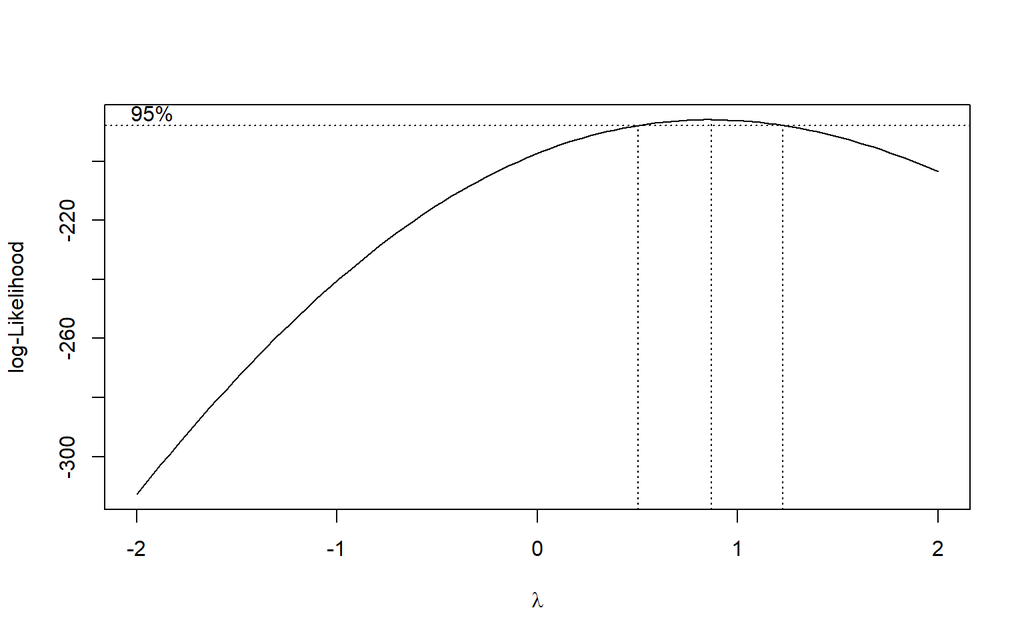

```r
index <- seq(1:125)

# Box-Cox
bc <- boxcox(dt.train$`PM2.5(ug/m3)` ~ index, lambda = seq(-2, 2, by = 0.1))
```

```r
# Nilai lambda optimum (rounded)
lambda_opt <- bc$x[which.max(bc$y)]
lambda_opt
```

```
## [1] 0.8686869
```

```r
# Selang kepercayaan 95% untuk lambda
ci_lambda <- bc$x[bc$y > max(bc$y) - 0.5 * qchisq(0.95, df = 1)]

# Batas bawah dan batas atas
ci_lower <- min(ci_lambda)
ci_upper <- max(ci_lambda)

c(Batas_Bawah = ci_lower, Batas_Atas = ci_upper)
```

```
## Batas_Bawah  Batas_Atas
##   0.5050505   1.1919192
```

# PENANGANAN KETIDAKSTASIONERAN

## Differencing

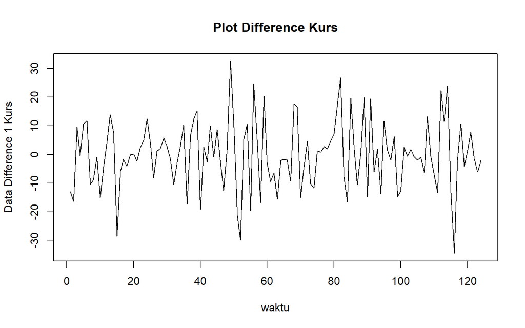

```r
# Dufferencing pertama
train.diff<-diff(dt.train$`PM2.5(ug/m3)`,differences = 1)

# Plot hasil differencing
plot.ts(train.diff, lty=1, xlab="waktu", ylab="Data Difference 1 Kurs", main="Plot Difference Kurs")
```

Berdasarkan plot data deret waktu, terlihat bahwa data sudah stasioner dalam rataan ditandai dengan data bergerak pada nilai tengah tertentu (tidak terdapat trend ataupun musiman pada data)

## Uji ACF data hasil differencing 1

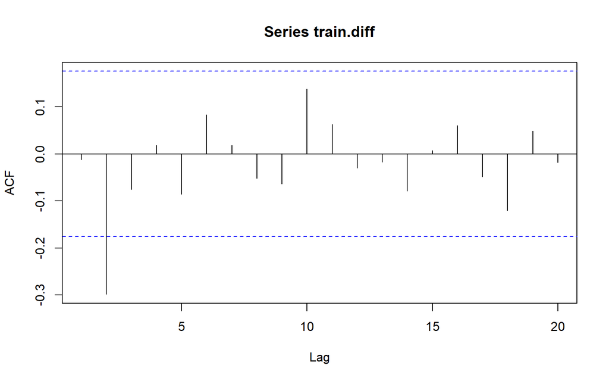

```r
acf(train.diff)
```

data sudah cut-off di lag 2, mengindikasikan data stasioner dalam rataan.

## Uji ADF data hasil differencing 1

```r
tseries::adf.test(train.diff)
```

```
##
##  Augmented Dickey-Fuller Test
##
## data:  train.diff
## Dickey-Fuller = -6.8474, Lag order = 4, p-value = 0.01
## alternative hypothesis: stationary
```

$H_0$ : Data tidak stasioner dalam rataan

$H_1$ : Data stasioner dalam rataan

Berdasarkan uji ADF tersebut, didapat *p-value* sebesar 0.01 yang lebih kecil dari taraf nyata 5% sehingga tolak $H_0$ atau data stasioner dalam rataan. Hal ini sesuai dengan hasil eksplorasi menggunakan plot time series dan plot ACF, sehingga dalam hal ini ketidakstasioneran data sudah berhasil ditangani dan dapat dilanjutkan ke pemodelan

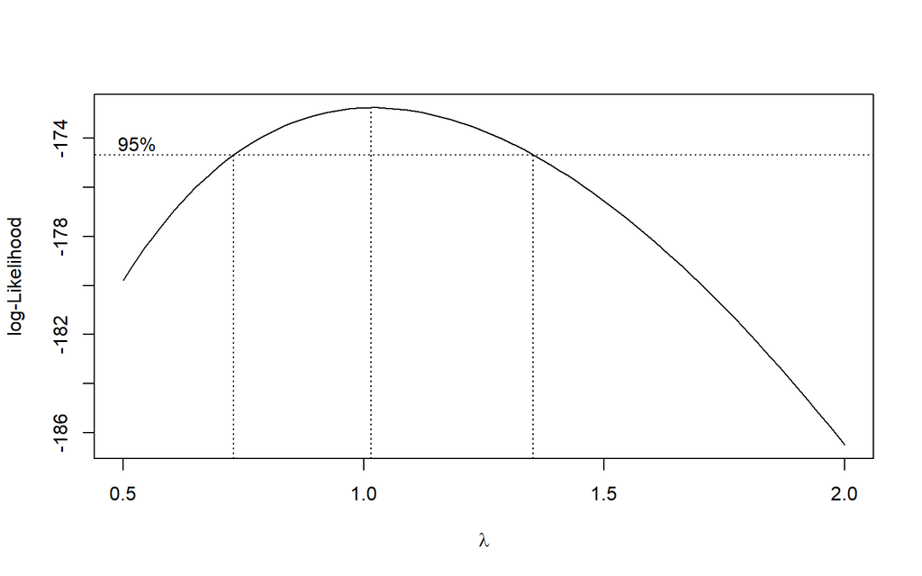

```r
# 1. Sesuaikan panjang index karena differencing menghilangkan 1 observasi awal
index_diff <- seq(1:length(train.diff))

# 2. Cek apakah ada nilai negatif/nol. Jika ada, tambahkan konstanta (c)
# agar nilai minimum data menjadi > 0 (misalnya menjadi 1)
min_val <- min(train.diff)

if (min_val <= 0) {
  c <- abs(min_val) + 1
  train.diff_shifted <- train.diff + c
} else {
  train.diff_shifted <- train.diff
}

# 3. Plot Box-Cox pada data yang sudah di-shift
bc_diff <- boxcox(train.diff_shifted ~ index_diff, lambda = seq(0.5, 2, by = 0.1))
```

```r
# 4. Nilai lambda optimum (rounded)
lambda_opt_diff <- bc_diff$x[which.max(bc_diff$y)]
print(paste("Lambda optimum setelah diff:", lambda_opt_diff))
```

```
## [1] "Lambda optimum setelah diff: 1.01515151515152"
```

```r
# 5. Selang kepercayaan 95% untuk lambda
ci_lambda_diff <- bc_diff$x[bc_diff$y > max(bc_diff$y) - 0.5 * qchisq(0.95, df = 1)]

# Batas bawah dan batas atas
ci_lower_diff <- min(ci_lambda_diff)
ci_upper_diff <- max(ci_lambda_diff)

c(Batas_Bawah = ci_lower_diff, Batas_Atas = ci_upper_diff)
```

```
## Batas_Bawah  Batas_Atas
##   0.7424242   1.3484848
```

Karena Lambda optimum hampir sama dengan 1 maka sudah tidak perlu transformasi boxcox. Sudah Stasioner dalam ragam

# IDENTIFIKASI MODEL

## Plot ACF

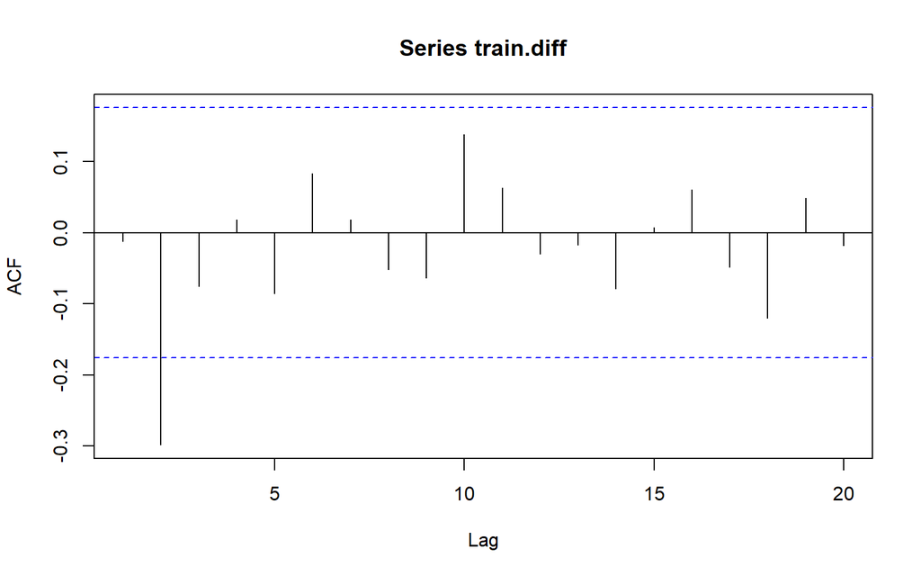

```r
acf(train.diff)
```

Berdasarkan plot tersebut, terlihat bahwa plot ACF cenderung *cuts off* pada lag ke 2, sehingga jika plot PACF dianggap *tails of*, maka model tentatifnya adalah ARIMA(0,1,2).

## Plot PACF

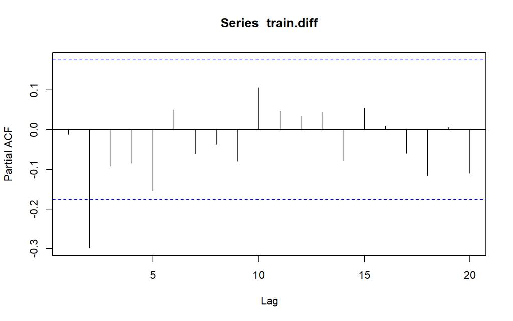

```r
pacf(train.diff)
```

Berdasarkan plot tersebut, terlihat bahwa plot PACF cenderung *cuts off* pada lag ke 2, sehingga jika plot ACF dianggap *tails of*, maka model tentatifnya adalah ARIMA(2,1,0).

Jika baik plot ACF maupun plot PACF keduanya dianggap tails of, maka model yang terbentuk adalah ARIMA(1,1,1)

## Plot EACF

```r
eacf(train.diff)
```

```
## AR/MA
##   0 1 2 3 4 5 6 7 8 9 10 11 12 13
## 0 o x o o o o o o o o o  o  o  o
## 1 o x o o o o o o o o o  o  o  o
## 2 x o o o o o o o o o o  o  o  o
## 3 x o x o o o o o o o o  o  o  o
## 4 x x x o o o o o o o o  o  o  o
## 5 x o x o o o o o o o o  o  o  o
## 6 x x o x o o o o o o o  o  o  o
## 7 x x o x x o o o o o o  o  o  o
```

Identifikasi model menggunakan plot EACF dilakukan dengan melihat ujung segitiga pada pola segitiga nol. Dalam hal ini model tentatif yang terbentuk adalah ARIMA(0,1,2), ARIMA(1,1,2), dan ARIMA(2,1,2).

# PENDUGA PARAMETER MODEL TENTATIF

## ARIMA(0,1,1)

```r
model1.da=Arima(train.diff, order=c(0,0,1),method="ML")
summary(model1.da)
```

```
## Series: train.diff
## ARIMA(0,0,1) with non-zero mean
##
## Coefficients:
##           ma1     mean
##       -0.0297  -0.0729
## s.e.   0.1445   1.0289
##
## sigma^2 = 141.6:  log likelihood = -482.03
## AIC=970.06   AICc=970.26   BIC=978.52
##
## Training set error measures:
##                        ME    RMSE      MAE      MPE     MAPE      MASE
## Training set -0.003157151 11.8034 8.967694 98.49839 98.49839 0.6979025
##                     ACF1
## Training set 0.009079193
```

```r
lmtest::coeftest(model1.da)
```

```
##
## z test of coefficients:
##
##            Estimate Std. Error z value Pr(>|z|)
## ma1       -0.029745   0.144492 -0.2059   0.8369
## intercept -0.072853   1.028873 -0.0708   0.9436
```

## ARIMA(1,1,0)

```r
model2.da=Arima(train.diff, order=c(1,0,0),method="ML")
summary(model2.da)
```

```
## Series: train.diff
## ARIMA(1,0,0) with non-zero mean
##
## Coefficients:
##           ar1     mean
##       -0.0117  -0.0751
## s.e.   0.0899   1.0479
##
## sigma^2 = 141.6:  log likelihood = -482.04
## AIC=970.08   AICc=970.28   BIC=978.54
##
## Training set error measures:
##                        ME     RMSE      MAE    MPE   MAPE      MASE
## Training set -0.001198898 11.80467 8.973532 99.024 99.024 0.6983568
##                      ACF1
## Training set -0.003480808
```

```r
lmtest::coeftest(model2.da)
```

```
##
## z test of coefficients:
##
##            Estimate Std. Error z value Pr(>|z|)
## ar1       -0.011731   0.089874 -0.1305   0.8961
## intercept -0.075102   1.047949 -0.0717   0.9429
```

## ARIMA(1,1,1)

```r
model3.da=Arima(train.diff, order=c(1,0,1),method="ML")
summary(model3.da)
```

```
## Series: train.diff
## ARIMA(1,0,1) with non-zero mean
##
## Coefficients:
##          ar1      ma1    mean
##       0.7989  -1.0000  0.2093
## s.e.  0.0586   0.0273  0.1274
##
## sigma^2 = 128.9:  log likelihood = -477.02
## AIC=962.04   AICc=962.38   BIC=973.32
##
## Training set error measures:
##                      ME     RMSE      MAE      MPE     MAPE      MASE
## Training set -0.9024789 11.21351 8.674821 104.6967 177.7159 0.6751099
##                    ACF1
## Training set 0.07672384
```

```r
lmtest::coeftest(model3.da)
```

```
##
## z test of coefficients:
##
##            Estimate Std. Error  z value Pr(>|z|)
## ar1        0.798901   0.058623  13.6278   <2e-16 ***
## ma1       -1.000000   0.027292 -36.6414   <2e-16 ***
## intercept  0.209283   0.127410   1.6426   0.1005
## ---
## Signif. codes:  0 '***' 0.001 '**' 0.01 '*' 0.05 '.' 0.1 ' ' 1
```

## ARIMA(1,1,2)

```r
model4.da=Arima(train.diff, order=c(1,0,2),method="ML")
summary(model4.da)
```

```
## Series: train.diff
## ARIMA(1,0,2) with non-zero mean
##
## Coefficients:
##          ar1      ma1      ma2    mean
##       0.2398  -0.3193  -0.3028  0.0256
## s.e.  0.2134   0.1979   0.0873  0.5055
##
## sigma^2 = 127.5:  log likelihood = -474.65
## AIC=959.31   AICc=959.82   BIC=973.41
##
## Training set error measures:
##                       ME   RMSE      MAE      MPE     MAPE      MASE
## Training set -0.09483566 11.109 8.516875 136.6367 179.4389 0.6628179
##                     ACF1
## Training set 0.008254634
```

```r
lmtest::coeftest(model4.da)
```

```
##
## z test of coefficients:
##
##            Estimate Std. Error z value  Pr(>|z|)
## ar1        0.239760   0.213412  1.1235 0.2612421
## ma1       -0.319280   0.197897 -1.6134 0.1066648
## ma2       -0.302843   0.087315 -3.4684 0.0005236 ***
## intercept  0.025636   0.505471  0.0507 0.9595511
## ---
## Signif. codes:  0 '***' 0.001 '**' 0.01 '*' 0.05 '.' 0.1 ' ' 1
```

## ARIMA(2,1,1)

```r
model5.da=Arima(train.diff, order=c(2,0,1),method="ML")
summary(model5.da)
```

```
## Series: train.diff
## ARIMA(2,0,1) with non-zero mean
##
## Coefficients:
##          ar1      ar2      ma1    mean
##       0.4933  -0.2745  -0.5768  0.0237
## s.e.  0.2031   0.0972   0.2061  0.5474
##
## sigma^2 = 127.7:  log likelihood = -474.73
## AIC=959.45   AICc=959.96   BIC=973.55
##
## Training set error measures:
##                       ME     RMSE      MAE      MPE     MAPE      MASE
## Training set -0.09366012 11.11512 8.489859 136.0352 176.8235 0.6607154
##                   ACF1
## Training set 0.0132795
```

```r
lmtest::coeftest(model5.da)
```

```
##
## z test of coefficients:
##
##            Estimate Std. Error z value Pr(>|z|)
## ar1        0.493300   0.203085  2.4290 0.015139 *
## ar2       -0.274467   0.097250 -2.8223 0.004768 **
## ma1       -0.576807   0.206140 -2.7981 0.005140 **
## intercept  0.023663   0.547389  0.0432 0.965519
## ---
## Signif. codes:  0 '***' 0.001 '**' 0.01 '*' 0.05 '.' 0.1 ' ' 1
```

## ARIMA (2,1,2)

```r
model6.da=Arima(train.diff, order=c(2,0,2),method="ML")
summary(model6.da)
```

```
## Series: train.diff
## ARIMA(2,0,2) with non-zero mean
##
## Coefficients:
##          ar1      ar2      ma1      ma2    mean
##       0.3228  -0.1355  -0.3962  -0.1812  0.0274
## s.e.  0.2732   0.2222   0.2681   0.2328  0.5258
##
## sigma^2 = 128.2:  log likelihood = -474.48
## AIC=960.96   AICc=961.68   BIC=977.88
##
## Training set error measures:
##                       ME     RMSE      MAE      MPE     MAPE    MASE
## Training set -0.09843621 11.09261 8.482722 136.3133 180.2398 0.66016
##                     ACF1
## Training set 0.003649822
```

```r
lmtest::coeftest(model6.da)
```

```
##
## z test of coefficients:
##
##            Estimate Std. Error z value Pr(>|z|)
## ar1        0.322813   0.273178  1.1817   0.2373
## ar2       -0.135465   0.222153 -0.6098   0.5420
## ma1       -0.396209   0.268066 -1.4780   0.1394
## ma2       -0.181208   0.232828 -0.7783   0.4364
## intercept  0.027441   0.525815  0.0522   0.9584
```

# RINGKASAN AIC

```r
model_tentatif <- data.frame(
  Model = c("ARIMA(0,1,1)","ARIMA(1,1,0)","ARIMA(1,1,1)", "ARIMA(1,1,2)",
            "ARIMA(2,1,1)", "ARIMA(2,1,2)"),
  AIC   = c(AIC(model1.da),AIC(model2.da), AIC(model3.da), AIC(model4.da), AIC(model5.da), AIC(model6.da)),
  BIC   = c(BIC(model1.da),BIC(model2.da), BIC(model3.da), BIC(model4.da), BIC(model5.da), BIC(model6.da))
)

model_tentatif
```

```
##          Model      AIC      BIC
## 1 ARIMA(0,1,1) 970.0578 978.5186
## 2 ARIMA(1,1,0) 970.0836 978.5445
## 3 ARIMA(1,1,1) 962.0412 973.3223
## 4 ARIMA(1,1,2) 959.3098 973.4112
## 5 ARIMA(2,1,1) 959.4509 973.5523
## 6 ARIMA(2,1,2) 960.9579 977.8796
```

# ANALISIS SISAAN

## Eksplorasi Sisaan

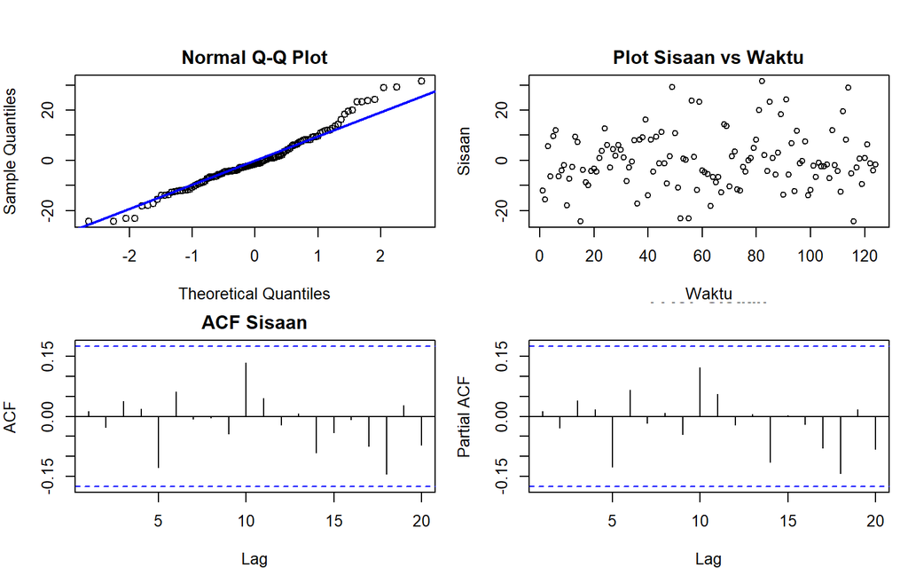

```r
sisaan.da <- model5.da$residuals

par(mfrow = c(2,2),
    mar = c(4,4,2,1),
    oma = c(0,0,2,0))

# Q-Q Plot
qqnorm(sisaan.da, main = "Normal Q-Q Plot")
qqline(sisaan.da, col = "blue", lwd = 2)

# Plot Sisaan vs Waktu
plot(sisaan.da, type = "p",
     main = "Plot Sisaan vs Waktu",
     xlab = "Waktu", ylab = "Sisaan")

# ACF
acf(sisaan.da, main = "ACF Sisaan")

# PACF
pacf(sisaan.da, main = "PACF Sisaan")
```

Berdasarkan Normal QQ Plot, secara eksploratif terlihat bahwa sisaan tidak sepenuhnya menyebar normal karena beberapa titik cenderung menyimpang dari garis 45∘ terutama pada ujung atas. Selain itu, lebar pita sebaran sisaan tampak seragam, yang mengindikasikan ragam sisaan homogen. plot ACF dan PACF sisaan dari model ARIMA(2,1,1) menunjukkan tidak adanya spike signifikan pada 20 lag pertama, sehingga secara visual sisaan dapat dianggap saling bebas. Kondisi ini akan diuji lebih lanjut dengan uji formal.